# Analiza n-gramowa amyloid

9 listopada 2015

## Amyloidy

Białka amyloidogenne zawierają *hot-spots*, krótkie sekwencje aminokwasów, które powodują agregowanie białek w zazwyczaj cytotoksyczne kompleksy (Fändrich 2012).

Agregaty amyloid są przyczyną różnych zaburzeń (m.in. choroby Alzheimera, Creutzfelda-Jacoba). Mimo podobieństw w procesie agregacji, białka amyloidogenne są zróżnicowane pod względem długości i składu aminokwasowego (Breydo and Uversky 2015).

## n-gramy (k-mery)

n-gramy (k-mery, k-tuple) to wektory o długości \(n\) zawierające znaki z sekwencji wejściowych.

Pierwotnie analiza n-gramów rozwijana była na potrzeby analizy języka naturalnego, ale ma również zastosowania w genomice (Fang et al. 2011), transkryptomice (Wang 2014) i proteomice (Guo et al. 2014).

## Przykładowe sekwencje

|  | P1 | P2 | P3 | P4 | P5 | P6 |
| --- | --- | --- | --- | --- | --- | --- |
| S1 | C | T | A | C | T | C |
| S2 | C | T | A | G | A | A |
| S3 | G | G | G | T | G | C |
| S4 | T | G | C | C | A | T |
| S5 | A | A | T | T | C | C |

S - sekwencje, P - pozycja nukleotydu.

## Zliczenia 1-gramów

|  | S1 | S2 | S3 | S4 | S5 |
| --- | --- | --- | --- | --- | --- |
| A | 1 | 3 | 0 | 1 | 2 |
| C | 3 | 1 | 1 | 2 | 2 |
| G | 0 | 1 | 4 | 1 | 0 |
| T | 2 | 1 | 1 | 2 | 2 |

## Zliczenia 2-gramów

|  | S1 | S2 | S3 | S4 | S5 |
| --- | --- | --- | --- | --- | --- |
| AA | 0 | 1 | 0 | 0 | 1 |
| CA | 0 | 0 | 0 | 1 | 0 |
| GA | 0 | 1 | 0 | 0 | 0 |
| TA | 1 | 1 | 0 | 0 | 0 |
| AC | 1 | 0 | 0 | 0 | 0 |
| CC | 0 | 0 | 0 | 1 | 1 |
| GC | 0 | 0 | 1 | 1 | 0 |
| TC | 1 | 0 | 0 | 0 | 1 |
| AG | 0 | 1 | 0 | 0 | 0 |
| CG | 0 | 0 | 0 | 0 | 0 |

[output cut: 6 more lines]

## Całkowita liczba n-gramów

\[n_\text{max} = u^n\]

\(n_\text{max}\): liczba wszystkich możliwych n-gramów

\(u\): liczba liter w alfabecie.

\(n\): długość n-gramu

## Całkowita liczba n-gramów

[interactive chart not shown]

## Informacja o pozycji

n-gramy mogą mieć przypisaną informację o pozycjach na których występują.

|  | P1 | P2 | P3 | P4 | P5 | P6 |
| --- | --- | --- | --- | --- | --- | --- |
| S1 | C | T | A | C | T | C |
| S2 | C | T | A | G | A | A |
| S3 | G | G | G | T | G | C |
| S4 | T | G | C | C | A | T |
| S5 | A | A | T | T | C | C |

## Pozycjonowane n-gramy

|  | S1 | S2 | S3 | S4 | S5 |
| --- | --- | --- | --- | --- | --- |
| 1_AA | 0 | 0 | 0 | 0 | 1 |
| 2_AA | 0 | 0 | 0 | 0 | 0 |
| 3_AA | 0 | 0 | 0 | 0 | 0 |
| 4_AA | 0 | 0 | 0 | 0 | 0 |
| 5_AA | 0 | 1 | 0 | 0 | 0 |
| 1_CA | 0 | 0 | 0 | 0 | 0 |
| 2_CA | 0 | 0 | 0 | 0 | 0 |
| 3_CA | 0 | 0 | 0 | 0 | 0 |
| 4_CA | 0 | 0 | 0 | 1 | 0 |
| 5_CA | 0 | 0 | 0 | 0 | 0 |

[output cut: 70 more lines]

## Liczba pozycjonowanych n-gramów

\[n_\text{max} = p \times u^n\]

\(n_\text{max}\): liczba wszystkich możliwych n-gramów

\(p\): liczba możliwych pozycji.

\(u\): liczba liter w alfabecie.

\(n\): długość n-gramu

## Liczba pozycjonowanych n-gramów

[interactive chart not shown]

## Nieciągłe n-gramy

n-gramy są nieciągłe, kiedy pomiędzy elementami n-gramu mogą występować przerwy.

|  | P1 | P2 | P3 | P4 | P5 | P6 |
| --- | --- | --- | --- | --- | --- | --- |
| S1 | C | T | A | C | T | C |
| S2 | C | T | A | G | A | A |
| S3 | G | G | G | T | G | C |
| S4 | T | G | C | C | A | T |
| S5 | A | A | T | T | C | C |

## Zliczenia 2-gramów z przerwą 1

|  | S1 | S2 | S3 | S4 | S5 |
| --- | --- | --- | --- | --- | --- |
| A_A | 0 | 1 | 0 | 0 | 0 |
| C_A | 1 | 1 | 0 | 1 | 0 |
| G_A | 0 | 1 | 0 | 0 | 0 |
| T_A | 0 | 0 | 0 | 0 | 0 |
| A_C | 0 | 0 | 0 | 0 | 0 |
| C_C | 1 | 0 | 0 | 0 | 0 |
| G_C | 0 | 0 | 0 | 1 | 0 |
| T_C | 1 | 0 | 1 | 1 | 2 |
| A_G | 0 | 0 | 0 | 0 | 0 |
| C_G | 0 | 0 | 0 | 0 | 0 |

[output cut: 6 more lines]

## Wybór informatywnych n-gramów

QuiPT (**Qui**ck **P**ermutation **T**est) szybko filtruje zmienne za pomocą testu statystycznego.

## Test permutacyjny

W teście permutacyjnym oznaczenia klas są losowo mieszane na potrzeby obliczania statystyki testowej.

\[ \text{p-value} = \frac{N_{T_P > T_R}}{N}, \]

gdzie \(N_{T_P > T_R}\) to liczba losowań, kiedy \(T_P\) (permutowana statystyka testowa) miała wartość krytyczniejszą niż \(T_R\) (statystyka testowa dla niespermutowanych danych).

Powyższy test permutacyjny jest równoważny dwustronnemu dokładnemu testowi Fishera. Ponieważ nasze wektory związane z n-gramami są bardzo rzadkie (wiele zer), uzyskujemy istotne przyspieszenie i poprawę jakości obliczanych p-wartości.

## Baza AmyLoad

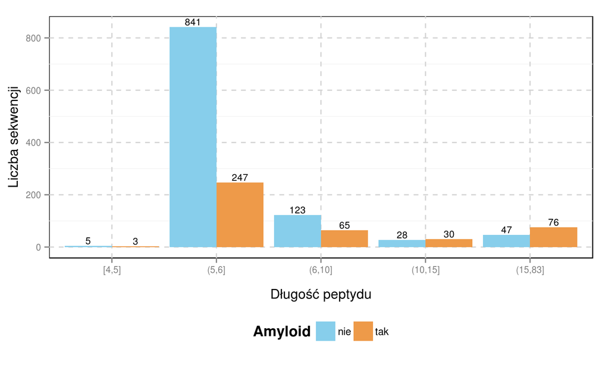

Sekwencje (1044 nie-amyloid i 421 amyloid) pobrano z bazy AmyLoad (Wozniak and Kotulska 2015).

## Grupowanie aminokwasów

- Wybrano dziewięć skal istotnych w procesie amyloidogenności: hydrofobowość, rozmiar, polarność, dostępność dla rozpuszczalnika i kontaktywność (Wozniak and Kotulska 2014).
- Wszystkie kombinacje skal (za każdym razem wybierając tylko jedną skalę dla danej właściwości) były gropowane używając dystansu euklidesowego i metody Warda.
- Każde grupowanie było podzielone na od trzech do sześciu kodowań tworząc 144 kodowania.
- Redundatne 51 kodowań (identycznych z innymi kodowaniami) zostało usuniętych.

## Przygotowanie danych

- Odrzucono sekwencje krótsze niż 6 aminokwasów.
- Dla każdej sekwencji odczytano zachodzące okna o długości 6. Każde okno zostało oznaczone tak samo jak sekwencja z której zostało wybrane.
- Z każdego okna wybrano 1-, 2- i 3-gramy (zarówno ciągłe jak i z przerwami).

## Przygotowanie danych

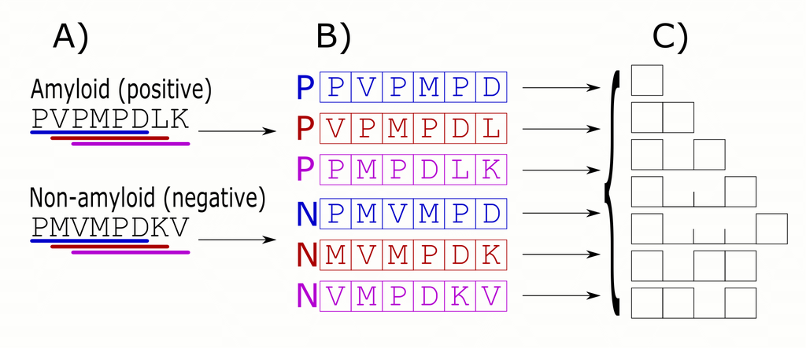

## Uczenie

- Dla każdego kodowania osobno, n-gramy przefiltrowano używając metody QuiPT i wykorzystano do uczenia lasów losowych (Liaw and Wiener 2002).
- Procedurę powtórzono na trzech zbiorach uczących: sekwencje o długości 6 aminokwasów, krótsze niż 11 aminokwasów i krótsze niż 15 aminokwasów.

## Wyniki walidacji krzyżowej

| Zbiór uczący | Liczba grup | ID kodowania | AUC | Czułość | Specyficzność |
| --- | --- | --- | --- | --- | --- |
| 6 | 4 | 1 | 0.657769085338976 | 0.508714912280702 | 0.691149497487437 |
| 6 | 4 | 2 | 0.637152380102266 | 0.562881578947368 | 0.610354899497487 |
| 6 | 3 | 3 | 0.808986452217226 | 0.532978070175439 | 0.89213756281407 |
| 6 | 3 | 4 | 0.798784348827471 | 0.438482456140351 | 0.897538944723618 |
| 6 | 3 | 5 | 0.794407519119721 | 0.603425438596491 | 0.829899497487437 |
| 6 | 3 | 6 | 0.795526304989862 | 0.618083333333333 | 0.822136934673367 |
| 6 | 3 | 7 | 0.811423547286873 | 0.536342105263158 | 0.894018844221106 |
| 6 | 3 | 8 | 0.798615352695495 | 0.588789473684211 | 0.849797110552764 |
| 6 | 3 | 9 | 0.794657403023891 | 0.569219298245614 | 0.858566582914573 |
| 6 | 3 | 10 | 0.803536538063123 | 0.530280701754386 | 0.901290201005025 |

[output cut: 275 more lines]

## Wyniki walidacji krzyżowej

[interactive chart not shown]

## Najlepsze kodowania

[output not shown]

## Najlepsze kodowania

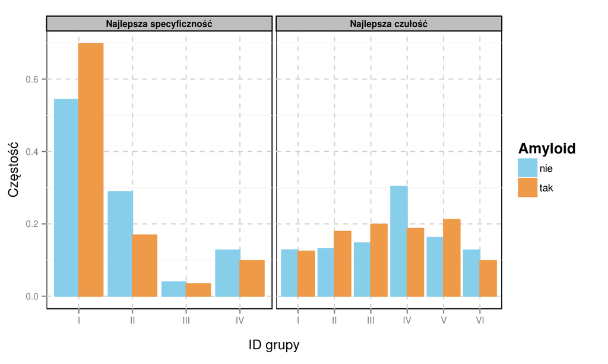

## Komitet klasyfikatorów

Dwaj najlepsze kodowania (najlepsza specyficzność i najlepsza czułość) mają różne obszary kompetencji

AmyloGram, komitet dwóch wymienionych klasyfikatorów, ma AUC \(0.8911\), czułość \(0.7473\) i specyficzność \(0.8684\).

## Porównanie z innymi klasyfikatorami

Wykorzystano zbiór danych **pep424** (Walsh et al. 2014) do porównania AmyloGramu z najlepszymi predyktorami amyloidogenności.

| Nazwa predyktora | AUC | Czułość | Specyficzność |
| --- | --- | --- | --- |
| AmyloGram | 0.8426 | 0.8054 | 0.7222 |
| PASTA2 | 0.7920 | 0.7248 | 0.8593 |
| FoldAmyloid | 0.7351 | 0.7517 | 0.7185 |

## Podsumowanie

AmyloGram pozwala nie tylko na przewidywanie potencjalnych hot-spots, ale równie na analizę cech świadczących o amyloidogenności.

biogram - pakiet **R** do analizy n-gramowej: https://cran.r-project.org/package=biogram

## References

Breydo, Leonid, and Vladimir N. Uversky. 2015. “Structural, Morphological, and Functional Diversity of Amyloid Oligomers.” *FEBS Letters*, July. doi:10.1016/j.febslet.2015.07.013.

Fang, Yu-Ching, Po-Ting Lai, Hong-Jie Dai, and Wen-Lian Hsu. 2011. “MeInfoText 2.0: Gene Methylation and Cancer Relation Extraction from Biomedical Literature.” *BMC Bioinformatics* 12 (1): 471. doi:10.1186/1471-2105-12-471.

Fändrich, Marcus. 2012. “Oligomeric Intermediates in Amyloid Formation: Structure Determination and Mechanisms of Toxicity.” *Journal of Molecular Biology*, Amyloid Structure, Function, and Molecular Mechanisms (Part II), 421 (4–5): 427–40. doi:10.1016/j.jmb.2012.01.006.

Guo, Shou-Hui, En-Ze Deng, Li-Qin Xu, Hui Ding, Hao Lin, Wei Chen, and Kuo-Chen Chou. 2014. “INuc-PseKNC: A Sequence-Based Predictor for Predicting Nucleosome Positioning in Genomes with Pseudo K-Tuple Nucleotide Composition.” *Bioinformatics* 30 (11): 1522–29. doi:10.1093/bioinformatics/btu083.

Liaw, Andy, and Matthew Wiener. 2002. “Classification and Regression by RandomForest.” *R News* 2 (3): 18–22. http://CRAN.R-project.org/doc/Rnews/.

Walsh, Ian, Flavio Seno, Silvio C. E. Tosatto, and Antonio Trovato. 2014. “PASTA 2.0: An Improved Server for Protein Aggregation Prediction.” *Nucleic Acids Research* 42 (W1): W301–7. doi:10.1093/nar/gku399.

Wang, Lin AND Chen, Ying AND Liu. 2014. “Comparison of Metatranscriptomic Samples Based on <italic>k-</italic>Tuple Frequencies.” *PLoS ONE* 9 (1). Public Library of Science: e84348. doi:10.1371/journal.pone.0084348.

Wozniak, Pawel P., and Malgorzata Kotulska. 2014. “Characteristics of Protein Residue-Residue Contacts and Their Application in Contact Prediction.” *Journal of Molecular Modeling* 20 (11). doi:10.1007/s00894-014-2497-9.

———. 2015. “AmyLoad: Website Dedicated to Amyloidogenic Protein Fragments.” *Bioinformatics (Oxford, England)*, June. doi:10.1093/bioinformatics/btv375.